[figure not shown]

# Visualizing Vector Data

Visualizing vector data allows us to better understand patterns, relationships, and trends in spatial datasets. By mapping features such as points, lines, and polygons, we can reveal insights about their locations, attributes, and interactions within a geographic context. This notebook demonstrates practical techniques for visualizing vector data using GeoLattice.

## Overview

A map gives each feature a position from its geometry and a meaning from the way it is drawn. The same county polygons can be a plain outline, a choropleth of diabetes prevalence, or one layer on an interactive web map. This notebook maps three geometry types with `geolattice.viz`:

- **Polygons**: US counties (`Data/00_shared/vector_data/USA/US_COUNTY.shp`) joined to county diabetes attributes (`Data/00_shared/tabular_data/usa_diabetes_data.csv`).
- **Points**: BGS well chemistry (`Data/00_shared/tabular_data/bgs_geochemical.csv`), written as a shapefile and projected to the Bangladesh boundary (`Data/00_shared/vector_data/Bangladesh/Shapefiles/BD_Banladesh_BUTM.shp`).
- **Lines**: street centerlines around Onondaga County, New York (`Data/00_shared/vector_data/USA/Ononda_Street_PROJ.shp`).

Static maps follow the [GeoPandas mapping guide](https://geopandas.org/en/stable/docs/user_guide/mapping.html). Interactive maps follow the [Folium gallery](https://geopandas.org/en/stable/gallery/plotting_with_folium.html): GeoPandas builds a Leaflet map with `GeoDataFrame.explore`, and Folium adds markers, choropleths, and heatmaps on top of a tile layer.

The notebook is organized in three parts:

1. **Polygon maps**: US counties joined to diabetes attributes: single-symbol, choropleth, categorical, cartographic elements, and an interactive Folium map.
2. **Point maps**: BGS well chemistry written as a shapefile, projected to the Bangladesh boundary, then mapped by arsenic and well class.
3. **Line maps**: Onondaga County street centerlines by speed and type, overlays, a tile basemap, and an interactive line layer.

A short **Mapping concepts** section covers kinds of map, classification, and color so the map calls later use a shared vocabulary.

## Setup

The next cell finds the repository root, applies the tutorial map style, and opens a shapefile as a GeoDataFrame. `open_vectors_data` is the same reader the vector tutorials use.

**Installation.** This notebook needs installation option 1 (vector, raster, CRS and visualization): `pip install "geolattice[core]"`. See "Installation options" in the GeoLattice README.

```python
# Display matplotlib figures inline in this Jupyter notebook.
%matplotlib inline

import sys  # tweak the Python import path so local geolattice is findable
from pathlib import Path  # filesystem paths for data folders

import geopandas as gpd  # GeoDataFrame construction for points and layers
import matplotlib.pyplot as plt  # figure layout helpers (subplots, tight_layout)
import pandas as pd  # tabular joins and CSV reads for attributes
from IPython.display import display  # pretty-print DataFrames in the notebook
```

```python
# ===================================================================
# Setup and helpers for reading layers and drawing maps.
# ===================================================================
# Locate the repo root, import geolattice.viz helpers, point DATA at sample data,
# apply map style, and define read_layer() for one-shapefile GeoDataFrames.

# Resolve the current working directory as a starting point for the root search.
ROOT = Path.cwd().resolve()
while not (ROOT / "Data" / "00_shared" / "vector_data").is_dir():
    if ROOT.parent == ROOT:
        raise FileNotFoundError("Could not find Data/00_shared/vector_data from the working directory.")
    ROOT = ROOT.parent
sys.path.insert(0, str(ROOT))

from geolattice.vector import open_vectors_data, write_shapefile  # open/write vector layers
from geolattice.viz import (  # mapping helpers and shared color name lists
    CATEGORICAL,  # named categorical colormaps
    DIVERGING,  # named diverging colormaps
    EDGE,  # default edge color for boundaries
    FACE,  # default face color for filled polygons
    SEQUENTIAL,  # named sequential colormaps
    add_geojson,  # add a GeoJSON overlay to a Folium map
    add_labels,  # place text labels on a matplotlib axes
    add_layer_control,  # Folium layer switcher control
    add_markers,  # Folium marker helper (imported for API completeness)
    apply_map_style,  # shared matplotlib style for tutorial maps
    cartographic_elements,  # north arrow / scale bar helpers
    interactive_map,  # Folium choropleth / categorical maps
    plot_bar,  # simple bar chart from a DataFrame column
    plot_boundary,  # outline-only polygon map
    plot_categorical,  # categorical polygon/point map
    plot_choropleth,  # continuous or classified choropleth
    plot_histogram,  # attribute histogram
    plot_layer,  # single-layer map
    plot_layers,  # multi-layer map composition
    plot_scatter,  # scatter plot of two attributes
)  # close this call

DATA = ROOT / "Data" / "00_shared"  # shared sample data root used by relative paths below
assert DATA.is_dir(), DATA  # fail early if the data folder is missing

pd.set_option("display.max_columns", 12)  # show more columns in previews
pd.set_option("display.width", 120)  # wider console width for DataFrame prints
apply_map_style()  # apply the shared GeoLattice matplotlib map style


# Helper: open one shapefile as a GeoDataFrame.
def read_layer(relative):
    # Docstring for this helper.
    """Open one shapefile and return a GeoDataFrame without the reader fid."""
    path = DATA / relative  # resolve the relative path under DATA
    # Open with the GeoLattice reader and convert the layer to a GeoDataFrame.
    with open_vectors_data(path) as dataset:
        frame = dataset.to_dataframe()  # attribute table + geometry column
        crs = frame.crs  # remember CRS before any column drops
    # Drop the internal reader fid if present so it does not clutter plots.
    if "fid" in frame.columns:
        frame = frame.drop(columns="fid")  # remove the fid column
    return gpd.GeoDataFrame(frame, geometry="geometry", crs=crs)  # typed GeoDataFrame


print(f"Data folder: {DATA}")  # confirm the resolved data root
print("Sequential:", ", ".join(SEQUENTIAL))  # list sequential colormap names
print("Diverging:", ", ".join(DIVERGING))  # list diverging colormap names
print("Categorical:", ", ".join(CATEGORICAL))  # list categorical colormap names
```

```
Data folder: /home/zia207/Github/GeoLattice/Data/00_shared
Sequential: viridis, OrRd, YlGnBu, Blues, plasma
Diverging: RdBu_r, BrBG, PiYG, coolwarm
Categorical: tab10, tab20, Set2, Dark2, rainbow
```

## Mapping concepts

The next three sections define the vocabulary used in the maps below: kinds of map, classification schemes, and color ramps.

### Kinds of map

**Single-symbol map.** Every feature uses the same fill, line, or marker. This is a reference map: it shows where the features are, and it is the base layer under a choropleth or a set of sample points.

**Choropleth.** Each area is colored from a numeric attribute, such as the percent of adults with diabetes. An *unclassed* choropleth stretches one continuous colormap from the minimum to the maximum, so similar values get similar colors. A *classified* choropleth groups the values into classes first and then paints each class with one color from the ramp.

**Categorical map.** Color encodes a name or a code, such as urban or rural, rather than a quantity. The classes have no order, so a qualitative palette keeps neighbors distinct. A sequential ramp would imply a ranking that the categories do not have.

**Graduated point map.** The point stays a point. Color or size carries the measurement, such as arsenic concentration at a well. A point choropleth answers "how much is here"; a single-symbol point map only answers "a sample was taken here."

**Line map.** Color or width carries a property of the line, such as a posted speed. Functional class and street type are categories; a speed limit can be treated as a category too, because the values are a short list of posted limits rather than a smooth surface.

**Multi-layer map.** Polygons, lines, and points share one axes. Layers that do not share a coordinate reference system will not line up, so reproject every layer to the CRS of the first one before drawing. Draw areas underneath and points or lines on top. A lower `zorder` is drawn first.

**Interactive map.** Folium places the same layers on a Leaflet map that can be panned and zoomed. Popups and tooltips read attributes, and a layer control turns layers on and off. Leaflet reads longitude and latitude, so `geolattice.viz` reprojects layers that use another CRS to EPSG:4326. Tile sets such as `OpenStreetMap` and `OpenTopoMap` supply the background, the same built-in tiles the Folium gallery uses.

### Classification

An unclassed map is faithful to the numbers and hard to read when a few large values take most of the color ramp. Classification cuts the range into classes so the legend has a handful of colors a reader can match.

`plot_choropleth(..., scheme=...)` passes the scheme name through to mapclassify, which is what GeoPandas uses. `k` is the number of classes. Five is a useful start: fewer classes hide differences, and more classes are difficult to tell apart in the legend.

| Scheme | What a class contains |
| --- | --- |
| `quantiles` | About the same number of features. A skewed distribution still uses the full ramp. |
| `equal_interval` | Equal steps of the attribute, `(max - min) / k`. Easy to explain. Outliers can leave a class empty. |
| `natural_breaks` | Jenks breaks that keep similar values together and split values that are far apart. |
| `fisher_jenks` | Another optimal-break method, close to natural breaks. |
| `std_mean` | Classes built from the mean and the standard deviation. |
| `user_defined` | Breaks you supply, for a threshold or a published standard. |

GeoPandas also accepts `percentiles`, `box_plot`, `headtail_breaks`, `maximum_breaks`, `jenks_caspall`, and `max_p_classifier`. Pass extra arguments to the classifier with `classification_kwds`.

The scheme changes the story. Quantiles of a right-skewed rate will look more even than equal intervals of the same rate, because equal intervals give the long tail a class of its own and pack most counties into the lower classes.

### Color

Match the palette to the kind of attribute. The names below are Matplotlib colormaps; the full set is in [Choosing Colormaps in Matplotlib](https://matplotlib.org/stable/tutorials/colors/colormaps.html).

- **Sequential** ramps (`OrRd`, `YlGnBu`, `viridis`) run from light to dark. Use one for a quantity that grows in one direction, such as a rate or a concentration.
- **Diverging** ramps (`RdBu_r`, `BrBG`) use two hues and a light middle. Use one when the value is a difference from a midpoint, and set `vmin` and `vmax` so that midpoint sits in the middle of the ramp.
- **Qualitative** ramps (`tab10`, `Set2`) keep neighboring classes distinct. Use one for categories.

`SEQUENTIAL`, `DIVERGING`, and `CATEGORICAL` in `geolattice.viz` hold those names. `FACE` and `EDGE` are the single-symbol fill and outline used throughout the tutorials.

A feature with a missing attribute is skipped unless `missing_kwds` assigns it a color, an edge, a hatch, and a legend label. That is how a county with no diabetes record stays visible instead of disappearing from the map.

## Part 1: Polygon maps: US counties and diabetes

`US_COUNTY.shp` is a county polygon layer in NAD83 Albers (meters). `usa_diabetes_data.csv` has one row per county. The shared key is `FIPS`. The shapefile stores FIPS as a number (`1001.0`); the table stores it as an integer (`1001`). Casting both to integer makes the join exact.

The table has 3,107 rows and the shapefile has 3,108 counties. Shannon County, South Dakota (FIPS 46113), has no row in the diabetes table, so its attributes stay empty after a left join. Later, `missing_kwds` draws that county on purpose instead of leaving a hole.

```python
# Load US counties, join diabetes/health attributes on FIPS, and preview the join.
counties = read_layer("vector_data/USA/US_COUNTY.shp")  # county polygons
diabetes = pd.read_csv(DATA / "tabular_data/usa_diabetes_data.csv")  # health CSV

counties["FIPS"] = counties["FIPS"].astype(int)  # integer FIPS for a clean join key
diabetes["FIPS"] = diabetes["FIPS"].astype(int)  # match counties FIPS dtype

# Columns to pull from the diabetes table onto the county polygons.
attributes = [
    "FIPS",  # join key
    "POP_Total",  # total population
    "Diabetes_count",  # count of adults with diabetes
    "Diabetes_per",  # diabetes prevalence percent
    "Obesity",  # obesity rate
    "Access_Excercise",  # exercise access indicator (source spelling)
    "Physical_Inactivity",  # inactivity rate
    "PCP_rate",  # primary-care physician rate
    "Food_Env_Index",  # food environment index
    "SVI",  # social vulnerability index
    "Urban_Rural",  # urban/rural class label
]  # end list
# Left join keeps every county and fills unmatched health fields with NaN.
counties = counties.merge(diabetes[attributes], on="FIPS", how="left")

print(f"Counties: {len(counties)}")  # number of county features after the join
print(f"CRS: {counties.crs.name}")  # CRS name on the county layer
print(f"Matched diabetes values: {int(counties['Diabetes_per'].notna().sum())}")  # non-null rates
display(counties.loc[counties["Diabetes_per"].isna(), ["FIPS", "STATE", "COUNTY"]])  # unmatched rows
display(counties[["STATE", "COUNTY", "FIPS", "Diabetes_per", "Obesity", "Urban_Rural", "REGION"]].head())  # preview
```

```
Counties: 3108
CRS: NAD_1983_Albers
Matched diabetes values: 3107
```

|  | FIPS | STATE | COUNTY |
| --- | --- | --- | --- |
| 1710 | 46113 | South Dakota | Shannon County |

|  | STATE | COUNTY | FIPS | Diabetes_per | Obesity | Urban_Rural | REGION |
| --- | --- | --- | --- | --- | --- | --- | --- |
| 0 | Alabama | Franklin County | 1059 | 9.38 | 27.38 | Rural | South |
| 1 | Georgia | Fannin County | 13111 | 8.34 | 23.40 | Rural | South |
| 2 | Iowa | Kossuth County | 19109 | 8.44 | 32.46 | Rural | Midwest |
| 3 | Oklahoma | Ottawa County | 40115 | 10.44 | 31.76 | Urban | South |
| 4 | Pennsylvania | Susquehanna County | 42115 | 7.84 | 28.70 | Rural | Northeast |

### Single-symbol map and boundary

A single fill shows the county fabric without an attribute. `plot_boundary` draws `GeoSeries.boundary` instead, so the interior stays empty. That is clearer than `facecolor="none"`: in Matplotlib, `None` means "use the default color," while the string `"none"` means "draw no fill."

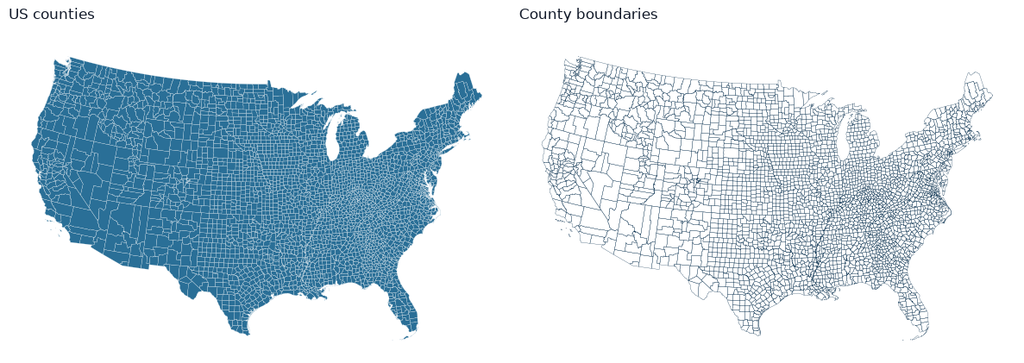

```python
# Side-by-side filled county map and boundary-only outline map.
fig, axes = plt.subplots(1, 2, figsize=(12, 5))  # two panels sharing one figure
# Draw one map layer.
plot_layer(
    counties,  # filled county polygons
    "US counties",  # left-panel title
    ax=axes[0],  # draw into the left axes
    facecolor=FACE,  # shared face color from geolattice.viz
    edgecolor="white",  # light edges between counties
    linewidth=0.15,  # thin county borders
    axis_off=True,  # hide axis ticks and spines
)  # close this call
# Draw polygon outlines only.
plot_boundary(
    counties,  # outline-only rendering of the same layer
    "County boundaries",  # right-panel title
    ax=axes[1],  # draw into the right axes
    edgecolor=EDGE,  # shared edge color from geolattice.viz
    linewidth=0.2,  # slightly thicker boundary lines
    axis_off=True,  # hide axis ticks and spines
)  # close this call
fig.tight_layout()  # reduce unused whitespace between panels
plt.show()  # display the figure in the notebook
```

### Unclassed choropleth

`column="Diabetes_per"` paints each county by the percent of adults with diabetes. `OrRd` is a sequential ramp: low rates are light, high rates are dark. With no `scheme`, every distinct value gets its own step along that ramp, and the legend is a continuous colorbar.

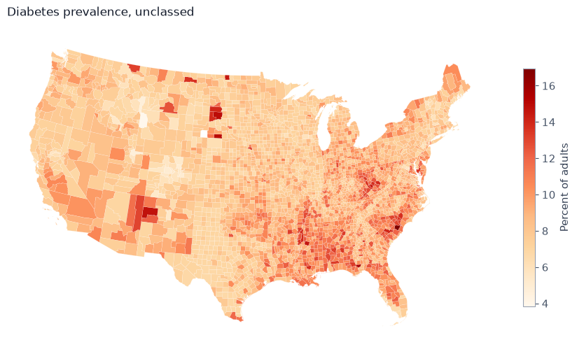

```python
# Continuous (unclassed) choropleth of diabetes prevalence with an OrRd ramp.
plot_choropleth(
    counties,  # county polygons with Diabetes_per
    "Diabetes_per",  # attribute column to color by
    "Diabetes prevalence, unclassed",  # map title
    cmap="OrRd",  # sequential orange-red colormap
    legend_kwds={"label": "Percent of adults", "shrink": 0.6},  # colorbar label/size
    linewidth=0.1,  # thin county borders
    figsize=(9, 6),  # figure size in inches
    axis_off=True,  # hide axis ticks and spines
)  # close this call
```

### What the classes contain

The same `Diabetes_per` values, cut five ways. The printed breaks are the upper edge of each class. Quantiles keep the counts almost equal. Equal interval spaces the breaks evenly from the minimum to the maximum, so the upper classes hold fewer counties. Natural breaks and Fisher-Jenks place the breaks where the values cluster. Standard-deviation classes are centered on the mean rather than on a requested `k`.

```python
# Compare common classification schemes on diabetes prevalence with mapclassify.
import mapclassify  # choropleth classification algorithms

values = counties["Diabetes_per"].dropna()  # drop NaNs before classifying
# Build one classifier per named scheme (most use k=5 classes).
classifiers = {
    "Quantiles": mapclassify.Quantiles(values, k=5),  # equal-count classes
    "Equal interval": mapclassify.EqualInterval(values, k=5),  # equal-width classes
    "Natural breaks": mapclassify.NaturalBreaks(values, k=5),  # Jenks-style breaks
    "Fisher-Jenks": mapclassify.FisherJenks(values, k=5),  # optimal Fisher-Jenks
    "Mean and standard deviation": mapclassify.StdMean(values),  # mean +/- std classes
}  # end mapping
# Print break edges and class counts for each scheme.
for name, classifier in classifiers.items():
    breaks = ", ".join(f"{edge:.2f}" for edge in classifier.bins)  # formatted break edges
    counts = ", ".join(str(count) for count in classifier.counts)  # features per class
    print(f"{name}")  # scheme name header
    print(f"  breaks: {breaks}")  # class upper edges
    print(f"  counts: {counts}")  # class membership counts
```

```
Quantiles
  breaks: 7.26, 7.90, 8.70, 9.84, 16.96
  counts: 636, 611, 631, 611, 618
Equal interval
  breaks: 6.46, 9.09, 11.71, 14.34, 16.96
  counts: 78, 2045, 836, 141, 7
Natural breaks
  breaks: 7.48, 8.58, 9.84, 11.50, 16.96
  counts: 841, 956, 692, 447, 171
Fisher-Jenks
  breaks: 7.46, 8.54, 9.82, 11.50, 16.96
  counts: 826, 935, 720, 455, 171
Mean and standard deviation
  breaks: 5.46, 7.03, 10.16, 11.73, 16.96
  counts: 12, 412, 2180, 357, 146
```

### Classified choropleths

The four maps below use one colormap and five classes. Only the scheme changes. Quantiles spread the counties across the ramp. Equal interval reserves the darkest class for the high tail, so most of the country stays in the lighter classes. Natural breaks and Fisher-Jenks sit between those two: the classes follow clumps in the data rather than equal counts or equal width.

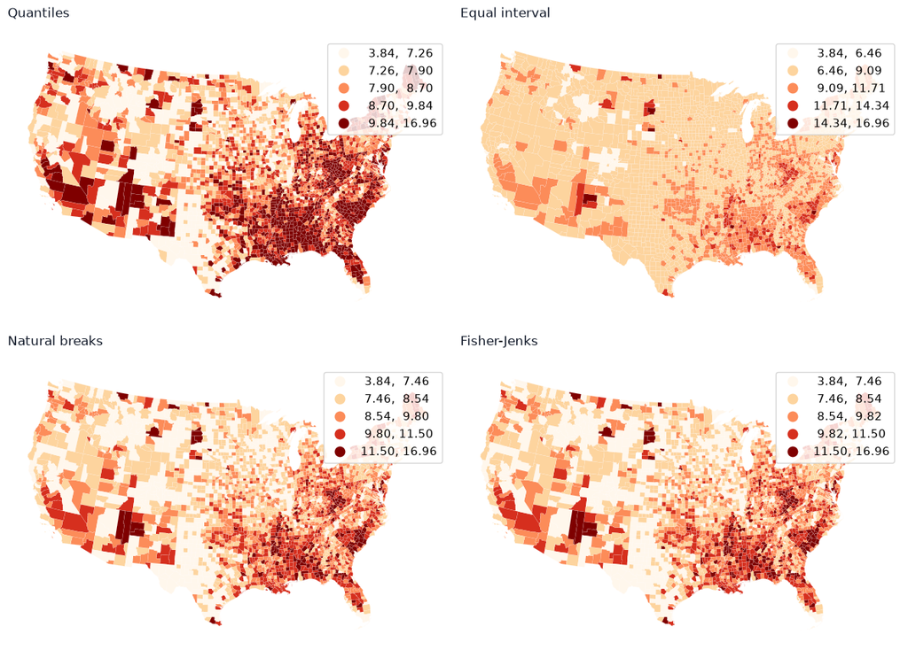

```python
# Four-panel choropleth comparing quantiles, equal interval, natural breaks, Fisher-Jenks.
schemes = [
    ("quantiles", "Quantiles"),  # equal-count classes
    ("equal_interval", "Equal interval"),  # equal-width classes
    ("natural_breaks", "Natural breaks"),  # Jenks-style breaks
    ("fisher_jenks", "Fisher-Jenks"),  # Fisher-Jenks optimal breaks
]  # end list
fig, axes = plt.subplots(2, 2, figsize=(12, 9))  # 2x2 grid of map panels
# Draw one classified choropleth into each axes panel.
for ax, (scheme, title) in zip(axes.ravel(), schemes):
    # Draw a choropleth map.
    plot_choropleth(
        counties,  # county polygons
        "Diabetes_per",  # attribute to classify
        title,  # panel title from the schemes list
        cmap="OrRd",  # shared sequential colormap
        scheme=scheme,  # mapclassify scheme name
        k=5,  # number of classes
        ax=ax,  # target axes in the 2x2 grid
        linewidth=0.08,  # thin borders for dense national map
        axis_off=True,  # hide axis ticks and spines
        show=False,  # defer plt.show until all panels are drawn
    )  # close this call
fig.tight_layout()  # tighten spacing among the four panels
plt.show()  # display the finished figure
```

### Breaks you choose

`scheme="user_defined"` keeps the class edges fixed when you compare places or years. The bins below are round cuts in percentage points, passed through `classification_kwds`. They are a cartographic choice, not a clinical threshold. A county above the last bin falls in the top class.

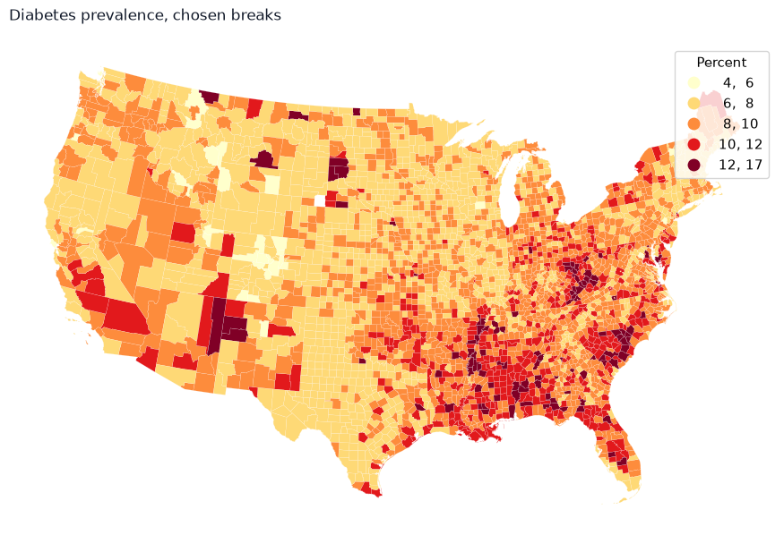

```python
# Choropleth with user-defined class breaks at 6, 8, 10, and 12 percent.
plot_choropleth(
    counties,  # county polygons
    "Diabetes_per",  # attribute column
    "Diabetes prevalence, chosen breaks",  # map title
    cmap="YlOrRd",  # yellow-orange-red sequential ramp
    scheme="user_defined",  # use explicit bins instead of an algorithm
    classification_kwds={"bins": [6, 8, 10, 12]},  # upper edges of custom classes
    linewidth=0.1,  # thin county borders
    legend_kwds={"title": "Percent", "fmt": "{:.0f}"},  # legend title and integer format
    figsize=(9, 6),  # figure size in inches
    axis_off=True,  # hide axis ticks and spines
)  # close this call
```

### A diverging ramp

A sequential ramp is the wrong tool when the question is "above or below a reference." Subtracting the national median puts that reference at zero. `RdBu_r` paints counties below the median blue and counties above it red. `vmin` and `vmax` are symmetric, so zero stays in the middle of the ramp. Counties farther out than that span share the end color.

```
National median: 8.28%    color span: ±8.68 points
```

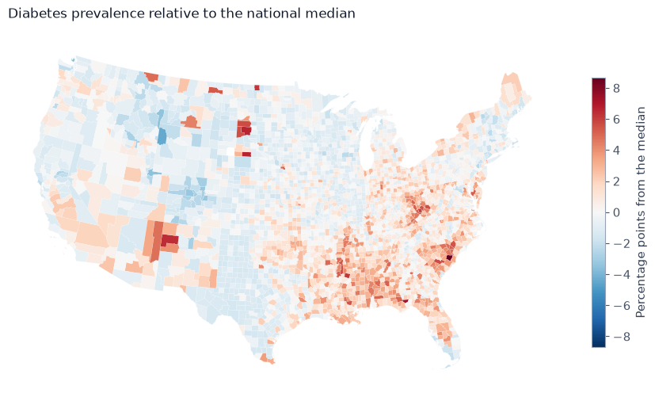

```python
# Diverging map of diabetes prevalence relative to the national median.
median_rate = counties["Diabetes_per"].median()  # national median prevalence
counties["Diabetes_vs_median"] = counties["Diabetes_per"] - median_rate  # signed deviation
span = counties["Diabetes_vs_median"].abs().max()  # symmetric color limit
print(f"National median: {median_rate:.2f}%    color span: ±{span:.2f} points")  # summary

# Draw a choropleth map.
plot_choropleth(
    counties,  # county polygons with Diabetes_vs_median
    "Diabetes_vs_median",  # signed deviation from the median
    "Diabetes prevalence relative to the national median",  # map title
    cmap="RdBu_r",  # diverging red-blue (reversed so high=red)
    vmin=-span,  # lower color limit (symmetric)
    vmax=span,  # upper color limit (symmetric)
    linewidth=0.1,  # thin county borders
    legend_kwds={"label": "Percentage points from the median", "shrink": 0.6},  # colorbar
    figsize=(9, 6),  # figure size in inches
    axis_off=True,  # hide axis ticks and spines
)  # close this call
```

### Categorical map

```
Urban_Rural
Urban    1797
Rural    1310
NaN         1
```

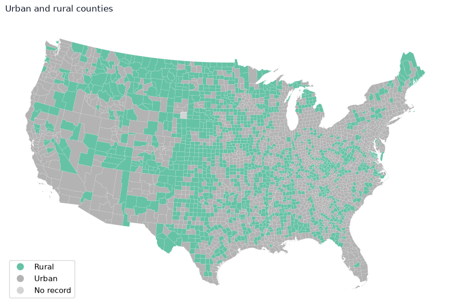

```python
# Categorical map of urban vs rural counties with a legend and missing style.
print(counties["Urban_Rural"].value_counts(dropna=False).to_string())  # class counts
# Draw a categorical attribute map.
plot_categorical(
    counties,  # county polygons
    "Urban_Rural",  # categorical attribute
    "Urban and rural counties",  # map title
    cmap="Set2",  # qualitative colormap
    linewidth=0.08,  # thin borders
    figsize=(9, 6),  # figure size in inches
    axis_off=True,  # hide axis ticks and spines
    missing_kwds={"color": "lightgrey", "label": "No record"},  # style for nulls
    legend_kwds={"loc": "lower left", "frameon": True},  # legend placement
)  # close this call
```

### Missing values

Shannon County is still in the layer, with an empty `Diabetes_per`. The default choropleth omits that polygon. `missing_kwds` draws it in grey, with a red outline and a hatch, and adds it to the legend. The reader can see the gap in the table instead of mistaking it for a low rate.

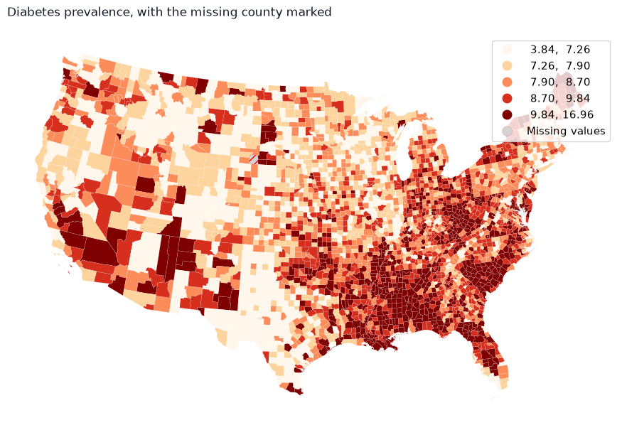

```python
# Quantile choropleth that highlights counties with missing diabetes values.
plot_choropleth(
    counties,  # county polygons
    "Diabetes_per",  # attribute column
    "Diabetes prevalence, with the missing county marked",  # map title
    cmap="OrRd",  # sequential colormap for non-missing values
    scheme="quantiles",  # equal-count classes
    k=5,  # five quantile classes
    linewidth=0.1,  # thin borders
    figsize=(9, 6),  # figure size in inches
    axis_off=True,  # hide axis ticks and spines
    missing_kwds={  # distinctive style for null Diabetes_per
        "color": "lightgrey",  # fill for missing counties
        "edgecolor": "red",  # red outline to draw the eye
        "hatch": "///",  # hatch pattern for missing polygons
        "label": "Missing values",  # legend label for missing
    },  # end this layer dict
)  # close this call
```

### The attribute beside the map

A choropleth is easier to read after a look at the distribution. The histogram shows the spread of `Diabetes_per`. The bars are the mean rate in each census region (one row per region, so the chart does not add the rates together). The scatter compares obesity with diabetes prevalence and colors each county by the social vulnerability index (`SVI`).

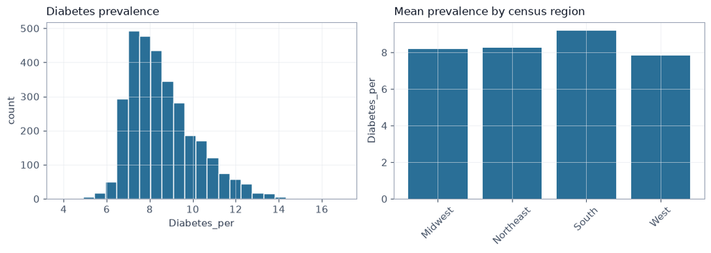

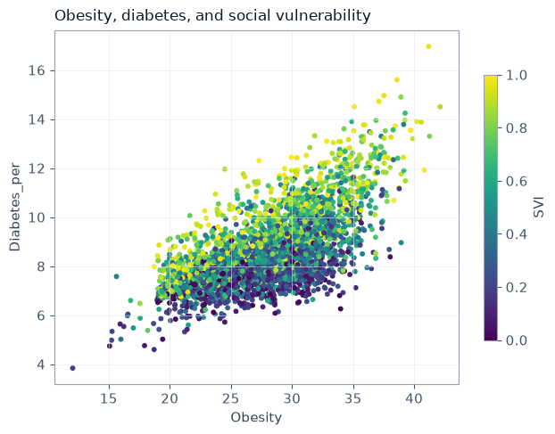

```python
# Supporting charts: diabetes histogram, regional mean bar chart, and scatter.
fig, axes = plt.subplots(1, 2, figsize=(11, 4))  # histogram + bar chart panels
# Draw an attribute histogram.
plot_histogram(
    counties,  # source table
    "Diabetes_per",  # column to bin
    title="Diabetes prevalence",  # histogram title
    bins=25,  # number of histogram bins
    ax=axes[0],  # left panel
    show=False,  # defer show until both panels are ready
)  # close this call
# Mean diabetes prevalence grouped by census REGION.
region_mean = counties.groupby("REGION")["Diabetes_per"].mean().to_frame()
# Draw a bar chart.
plot_bar(
    region_mean,  # one row per REGION
    "Diabetes_per",  # bar height column
    title="Mean prevalence by census region",  # bar chart title
    ax=axes[1],  # right panel
    show=False,  # defer show
)  # close this call
fig.tight_layout()  # tighten the two chart panels
plt.show()  # display histogram + bar chart

# Draw a scatter plot of two attributes.
plot_scatter(
    counties,  # county attribute table
    "Obesity",  # x-axis attribute
    "Diabetes_per",  # y-axis attribute
    column="SVI",  # color points by social vulnerability
    cmap="viridis",  # continuous colormap for SVI
    title="Obesity, diabetes, and social vulnerability",  # scatter title
    figsize=(6.5, 5),  # figure size in inches
)  # close this call
```

### Labels, a north arrow, and a scale bar

Labels on all 3,108 counties would cover the map. The New York counties are a readable extent: a quantile choropleth, a north arrow, and a scale bar. Names are drawn for the highest-rate counties that are large enough to hold a label. Bronx and Queens are in that top eight, and they are listed in the table under the map; a name drawn on either borough would cover it. The axes are padded so a name on the state border is not clipped. The layer is in an equal-area projection whose unit is the meter. `cartographic_elements` reads that unit from the CRS and labels the bar in kilometres once the distance reaches 1 km.

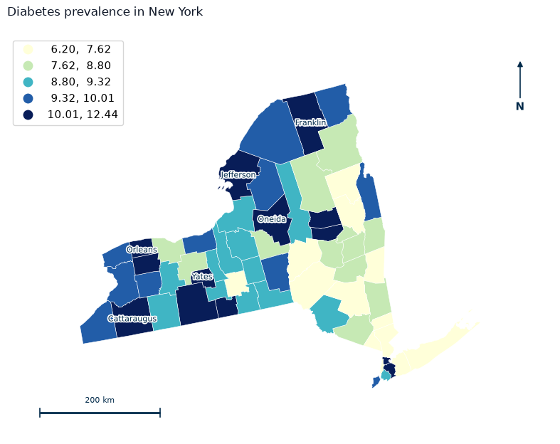

|  | COUNTY | Diabetes_per | Urban_Rural |
| --- | --- | --- | --- |
| 281 | Bronx County | 12.44 | Urban |
| 1953 | Franklin County | 11.20 | Urban |
| 1073 | Orleans County | 11.12 | Urban |
| 1215 | Cattaraugus County | 11.10 | Urban |
| 2622 | Jefferson County | 10.62 | Urban |
| 1031 | Yates County | 10.60 | Urban |
| 2873 | Oneida County | 10.60 | Urban |
| 2872 | Queens County | 10.54 | Urban |

```python
# Zoom to New York, label high-prevalence counties, and add cartographic elements.
new_york = counties.loc[counties["STATE"] == "New York"].copy()  # NY subset
highest = new_york.nlargest(8, "Diabetes_per").copy()  # top 8 prevalence counties
# Label only larger counties so small polygons are not overcrowded.
labeled = highest.loc[highest.geometry.area > 500 * 1e6].copy()
labeled["Name"] = labeled["COUNTY"].str.replace(" County", "", regex=False)  # short labels

# Assign ax.
ax = plot_choropleth(
    new_york,  # New York counties only
    "Diabetes_per",  # attribute for coloring
    "Diabetes prevalence in New York",  # map title
    cmap="YlGnBu",  # yellow-green-blue sequential ramp
    scheme="quantiles",  # equal-count classes
    k=5,  # five classes
    figsize=(8, 8),  # square-ish figure for the state
    linewidth=0.4,  # clearer county borders at state scale
    edgecolor="white",  # white borders between counties
    axis_off=True,  # hide axis ticks and spines
    show=False,  # return axes for further decoration
)  # close this call
xmin, xmax = ax.get_xlim()  # current x extent
ymin, ymax = ax.get_ylim()  # current y extent
pad_x = (xmax - xmin) * 0.12  # 12% horizontal padding
pad_y = (ymax - ymin) * 0.1  # 10% vertical padding
ax.set_xlim(xmin - pad_x, xmax + pad_x)  # expand x limits
ax.set_ylim(ymin - pad_y, ymax + pad_y)  # expand y limits
add_labels(ax, labeled, "Name", fontsize=8)  # place county name labels
cartographic_elements(ax, new_york)  # north arrow / scale bar
fig = ax.figure  # parent figure for layout
fig.tight_layout()  # reduce unused whitespace
plt.show()  # display the finished New York map
display(highest[["COUNTY", "Diabetes_per", "Urban_Rural"]].sort_values("Diabetes_per", ascending=False))  # table
```

### Interactive choropleth

`interactive_map` calls `GeoDataFrame.explore` and returns a Folium map. The quantile scheme and the tooltip fields are the same choices as the static map. OpenStreetMap tiles sit underneath, as in the [Folium gallery](https://geopandas.org/en/stable/gallery/plotting_with_folium.html). Hover a county for its name and rate. The New York subset keeps the notebook responsive; the same call accepts the full county layer.

```python
# Interactive Folium choropleth of New York diabetes prevalence.
center = new_york.to_crs(4326).geometry.union_all().centroid  # map center in lon/lat
# Build an interactive Folium map.
interactive_map(
    new_york,  # New York county polygons
    column="Diabetes_per",  # attribute for the choropleth
    cmap="YlGnBu",  # sequential colormap
    scheme="quantiles",  # equal-count classes
    k=5,  # five classes
    tooltip=["COUNTY", "Diabetes_per", "Urban_Rural"],  # hover fields
    tiles="OpenStreetMap",  # basemap tiles
    location=[center.y, center.x],  # Folium expects [lat, lon]
    zoom_start=7,  # initial zoom for statewide view
    height="520px",  # iframe height in the notebook
    name="Diabetes prevalence",  # layer name in the control
)  # close this call
```

Make this Notebook Trusted to load map: File -> Trust Notebook

[interactive chart not shown]

## Part 2: Point maps: BGS well chemistry in Bangladesh

`BD_Banladesh_BUTM.shp` is the Bangladesh boundary in the Bangladesh Transverse Mercator projection (BUTM). The attribute table does not carry place names, so the layer is a location frame.

`bgs_geochemical.csv` is a table, not a vector file. `LONG_DEG` and `LAT_DEG` are longitude and latitude in degrees. The next cell turns those columns into point geometry in WGS 84 (EPSG:4326), writes a shapefile, projects the points to the CRS of the boundary, and writes that projected shapefile. Both files go in `Data/00_shared/vector_data/output_folder/bangladesh`. The maps below read the projected shapefile, so they use what was written to disk.

`As` is arsenic in µg/L. The distribution is skewed: many wells are near the low end, and a long tail is far above it. `WELL_TYPE` has many spellings of the same kind of well, so `Well_class` keeps four groups, `STW`, `HTW`, `DTW`, and `TARA`, and puts the remaining names in `Other`.

```python
# Build BGS well points from CSV, write GCS and BUTM shapefiles, and summarize.
bangladesh = read_layer("vector_data/Bangladesh/Shapefiles/BD_Banladesh_BUTM.shp")  # boundary
chemistry = pd.read_csv(DATA / "tabular_data/bgs_geochemical.csv")  # well chemistry CSV


# Helper: collapse WELL_TYPE spellings into map classes.
def well_class(value):
    # Docstring for this helper.
    """Collapse the many WELL_TYPE spellings into five map classes."""
    # Null well types become the catch-all Other class.
    if pd.isna(value):
        return "Other"  # missing WELL_TYPE
    text = str(value).strip().upper()  # normalize spelling for matching
    # Keep the three common tube-well abbreviations as their own classes.
    if text in {"STW", "HTW", "DTW"}:
        return text  # STW / HTW / DTW
    # Any TARA spelling collapses to TARA.
    if "TARA" in text:
        return "TARA"  # Tara pump family
    return "Other"  # everything else


chemistry["Well_class"] = chemistry["WELL_TYPE"].map(well_class)  # add map classes
# Assign keep.
keep = [
    "SAMPLE_ID",  # sample identifier
    "LONG_DEG",  # longitude in degrees
    "LAT_DEG",  # latitude in degrees
    "Well_class",  # simplified well class
    "WELL_DEPTH",  # well depth
    "DIVISION",  # admin division
    "DISTRICT",  # admin district
    "As",  # arsenic concentration
]  # end list
# Build a GeoDataFrame of well points in EPSG:4326 from lon/lat columns.
wells_gcs = gpd.GeoDataFrame(
    chemistry[keep].copy(),  # attribute columns to keep
    geometry=gpd.points_from_xy(chemistry["LONG_DEG"], chemistry["LAT_DEG"]),  # point geoms
    crs="EPSG:4326",  # geographic CRS for lon/lat
)  # close this call

point_dir = DATA / "vector_data" / "output_folder" / "bangladesh"  # output folder
point_dir.mkdir(parents=True, exist_ok=True)  # create folder if needed
gcs_path = point_dir / "bgs_geochemical_gcs.shp"  # GCS shapefile path
butm_path = point_dir / "bgs_geochemical_butm.shp"  # projected shapefile path

write_shapefile(gcs_path, wells_gcs, overwrite=True)  # write lon/lat points
wells_butm = read_layer("vector_data/output_folder/bangladesh/bgs_geochemical_gcs.shp")  # reload GCS
wells_butm = wells_butm.to_crs(bangladesh.crs)  # reproject into the boundary CRS
write_shapefile(butm_path, wells_butm, overwrite=True)  # write projected points
wells_butm = read_layer("vector_data/output_folder/bangladesh/bgs_geochemical_butm.shp")  # reload BUTM

inside = int(wells_butm.within(bangladesh.union_all()).sum())  # wells inside the boundary
print(f"Boundary features: {len(bangladesh)}")  # boundary polygon count
print(f"Boundary CRS: {bangladesh.crs.name}")  # boundary CRS name
print(f"Wrote {gcs_path.name} in EPSG:4326")  # confirm GCS write
print(f"Wrote {butm_path.name} in the boundary CRS")  # confirm BUTM write
print(f"Wells: {len(wells_butm)}    inside the boundary: {inside}")  # counts
print(wells_butm["Well_class"].value_counts().to_string())  # class frequencies
display(wells_butm[["SAMPLE_ID", "Well_class", "DIVISION", "DISTRICT", "As", "WELL_DEPTH"]].head())  # preview
```

```
Boundary features: 369
Boundary CRS: Bangladesh Universal Tranverse Mercator (BUTM_2010)
Wrote bgs_geochemical_gcs.shp in EPSG:4326
Wrote bgs_geochemical_butm.shp in the boundary CRS
Wells: 3534    inside the boundary: 3497
Well_class
STW      1478
HTW      1001
TARA      565
DTW       441
Other      49
```

|  | SAMPLE_ID | Well_class | DIVISION | DISTRICT | As | WELL_DEPTH |
| --- | --- | --- | --- | --- | --- | --- |
| 0 | S98_02701 | DTW | Barisal | Jhalakati | 0.5 | 322.0 |
| 1 | S98_02715 | STW | Rajshahi | Pabna | 0.5 | 42.0 |
| 2 | S98_02979 | STW | Sylhet | Habiganj | 0.5 | 38.0 |
| 3 | S98_02992 | STW | Chittagong | Brahamanbaria | 0.5 | 20.0 |
| 4 | S98_03108 | DTW | Khulna | Khulna | 0.5 | 310.0 |

### Wells on the boundary

The boundary is drawn first. The wells go on top with a higher `zorder`. Both layers are in the BUTM CRS, because the points were projected to the boundary before they were drawn. One color means "a well was sampled here." Of the 3,534 wells, 3,497 fall inside the boundary. The other 37 sit just outside the polygon and stay on the map.

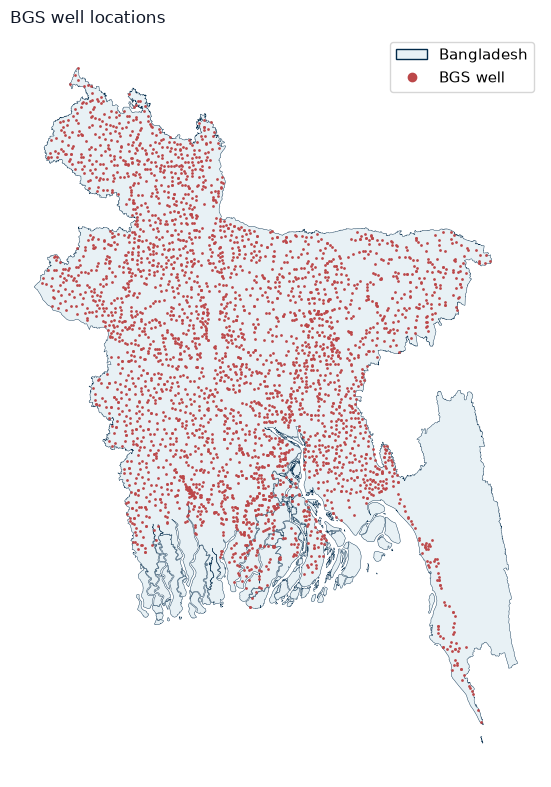

```python
# Static map of Bangladesh boundary with BGS well points overlaid.
plot_layers(
    # List of layer style dictionaries.
    [
        # One layer style dictionary.
        {
            "data": bangladesh,  # country boundary polygons
            "facecolor": "#E8F1F5",  # light blue-gray fill
            "edgecolor": EDGE,  # shared edge color
            "linewidth": 0.3,  # thin boundary stroke
            "label": "Bangladesh",  # legend label
            "zorder": 1,  # draw under the wells
        },  # end this layer dict
        # One layer style dictionary.
        {
            "data": wells_butm,  # well point layer
            "facecolor": "#BC4749",  # red point fill
            "markersize": 4,  # small markers for dense wells
            "linewidth": 0,  # no marker edge stroke
            "label": "BGS well",  # legend label
            "zorder": 2,  # draw above the boundary
        },  # end this layer dict
    ],  # end layer list
    title="BGS well locations",  # map title
    figsize=(7, 8),  # portrait figure for Bangladesh
    axis_off=True,  # hide axis ticks and spines
)  # close this call
```

### Graduated color by arsenic

Arsenic is a concentration, so the points use a sequential ramp. The first map is five quantiles: each class holds about the same number of wells, which spreads a skewed distribution across the ramp. The second map uses fixed breaks at 10, 50, and 200 µg/L. Ten is the WHO guideline and 50 is the Bangladesh drinking-water standard; 200 separates the upper tail. A well above the last break stays in the top class. The first quantile is the single value 0.25 µg/L, because that many wells share the low end of the table. Quantiles cannot split a tie. The fixed breaks do not have that problem.

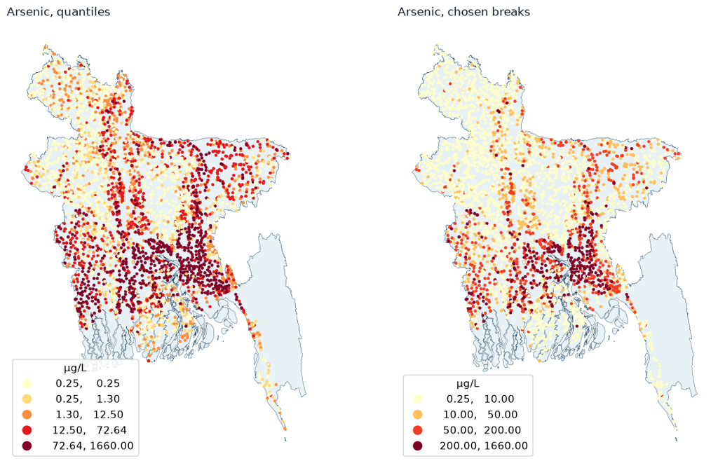

```python
# Two arsenic point maps: quantile classes vs user-defined breaks.
fig, axes = plt.subplots(1, 2, figsize=(12, 7))  # side-by-side arsenic maps
# Draw the Bangladesh boundary under each arsenic panel.
for ax, title in zip(axes, ["Arsenic, quantiles", "Arsenic, chosen breaks"]):
    # Draw one map layer.
    plot_layer(
        bangladesh,  # boundary underlay
        title,  # panel title
        ax=ax,  # target axes
        facecolor="#E8F1F5",  # light fill
        edgecolor=EDGE,  # boundary stroke color
        linewidth=0.25,  # thin boundary line
        axis_off=True,  # hide axes
        show=False,  # defer show
    )  # close this call
# Draw one map layer.
plot_layer(
    wells_butm,  # well points colored by arsenic
    column="As",  # arsenic concentration
    cmap="YlOrRd",  # sequential colormap
    scheme="quantiles",  # equal-count classes
    k=5,  # five quantile classes
    markersize=8,  # point size
    ax=axes[0],  # left panel
    legend=True,  # show class legend
    legend_kwds={"title": "µg/L", "loc": "lower left"},  # legend title/placement
    show=False,  # defer show
)  # close this call
# Draw one map layer.
plot_layer(
    wells_butm,  # well points again with custom breaks
    column="As",  # arsenic concentration
    cmap="YlOrRd",  # same colormap for comparison
    scheme="user_defined",  # explicit bins
    classification_kwds={"bins": [10, 50, 200]},  # WHO-style break points
    markersize=8,  # point size
    ax=axes[1],  # right panel
    legend=True,  # show class legend
    legend_kwds={"title": "µg/L", "loc": "lower left"},  # legend title/placement
    show=False,  # defer show
)  # close this call
fig.tight_layout()  # tighten the two panels
plt.show()  # display both arsenic maps
```

### Category: well class

`Well_class` is a code, so the point map is categorical. `tab10` keeps the classes distinct. A yellow-to-red ramp would imply that one well type is a larger amount of the same thing. The histogram shows why quantiles and fixed breaks tell different stories: most of the mass is at low concentrations, and a few wells are much higher.

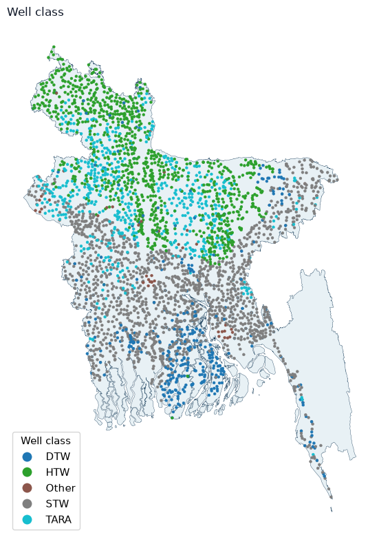

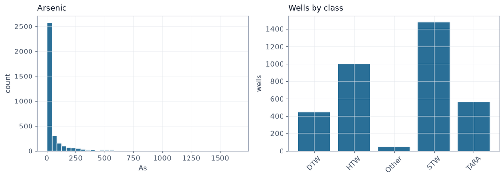

```python
# Categorical well-class map plus arsenic histogram and class-count bar chart.
ax = plot_layer(
    bangladesh,  # boundary underlay
    "Well class",  # map title
    facecolor="#E8F1F5",  # light fill
    edgecolor=EDGE,  # boundary stroke
    linewidth=0.25,  # thin boundary
    figsize=(7, 8),  # portrait figure
    axis_off=True,  # hide axes
    show=False,  # return axes for overlay
)  # close this call
# Draw a categorical attribute map.
plot_categorical(
    wells_butm,  # well points
    "Well_class",  # categorical column
    cmap="tab10",  # qualitative colormap
    ax=ax,  # draw on the boundary axes
    markersize=8,  # point size
    legend_kwds={"title": "Well class", "loc": "lower left"},  # legend
    show=False,  # defer show
)  # close this call
ax.figure.tight_layout()  # tighten the categorical map
plt.show()  # display the well-class map

fig, axes = plt.subplots(1, 2, figsize=(11, 4))  # histogram + bar chart
plot_histogram(wells_butm, "As", title="Arsenic", bins=40, ax=axes[0], show=False)  # As histogram
class_counts = wells_butm.groupby("Well_class").size().rename("wells").to_frame()  # counts by class
plot_bar(class_counts, "wells", title="Wells by class", ax=axes[1], show=False)  # class bar chart
fig.tight_layout()  # tighten chart panels
plt.show()  # display the charts
```

### Interactive maps

There are 3,534 wells, so the web maps use `GeoDataFrame.explore` through `interactive_map` rather than one CircleMarker per well. The first map colors wells by `Well_class`. The boundary is simplified by 500 m before it is sent to the browser: the shapefile has on the order of 140,000 vertices, and Leaflet does not need that density. The static maps above still use the original boundary.

Hover a well for its sample id, class, district, and arsenic. The layer control turns the boundary and the wells on and off.

```python
# Interactive map of well class with a simplified Bangladesh outline overlay.
well_center = [wells_butm["LAT_DEG"].mean(), wells_butm["LONG_DEG"].mean()]  # [lat, lon]
outline = bangladesh[["geometry"]].copy()  # geometry-only copy for overlay
outline["geometry"] = outline.geometry.simplify(500)  # simplify for lighter GeoJSON
# Assign class_map.
class_map = interactive_map(
    wells_butm,  # well points
    column="Well_class",  # categorical attribute
    categorical=True,  # treat values as categories
    cmap="tab10",  # qualitative colormap
    tooltip=["SAMPLE_ID", "Well_class", "DISTRICT", "As"],  # hover fields
    tiles="OpenStreetMap",  # basemap
    location=well_center,  # initial map center
    zoom_start=7,  # country-scale zoom
    height="520px",  # iframe height
    name="Well class",  # layer name
)  # close this call
# Add a GeoJSON overlay to the Folium map.
add_geojson(
    class_map,  # target Folium map
    outline,  # simplified boundary
    name="Bangladesh",  # overlay layer name
    color=EDGE,  # stroke color
    weight=1.2,  # stroke width
    fill_opacity=0.05,  # nearly transparent fill
)  # close this call
add_layer_control(class_map)  # enable layer toggles
class_map  # display the Folium map as the cell result
```

Make this Notebook Trusted to load map: File -> Trust Notebook

[interactive chart not shown]

### Interactive choropleth and a heatmap

The arsenic map uses the same 10, 50, and 200 µg/L breaks as the static map. The heatmap is the density view from the Folium gallery: `folium.plugins.HeatMap` takes `[latitude, longitude]` and shows where the samples cluster. It is not a map of the arsenic values. `OpenTopoMap` is the other built-in tile set used in that gallery.

```python
# Interactive arsenic map with the same Bangladesh outline overlay.
arsenic_map = interactive_map(
    wells_butm,  # well points
    column="As",  # arsenic concentration
    cmap="YlOrRd",  # sequential colormap
    scheme="user_defined",  # explicit class breaks
    classification_kwds={"bins": [10, 50, 200]},  # custom arsenic bins
    tooltip=["SAMPLE_ID", "Well_class", "DISTRICT", "As"],  # hover fields
    tiles="OpenStreetMap",  # basemap
    location=well_center,  # reuse the well-center location
    zoom_start=7,  # country-scale zoom
    height="520px",  # iframe height
    name="Arsenic",  # layer name
)  # close this call
# Add a GeoJSON overlay to the Folium map.
add_geojson(
    arsenic_map,  # target Folium map
    outline,  # simplified boundary
    name="Bangladesh",  # overlay layer name
    color=EDGE,  # stroke color
    weight=1.2,  # stroke width
    fill_opacity=0.05,  # nearly transparent fill
)  # close this call
add_layer_control(arsenic_map)  # enable layer toggles
arsenic_map  # display the Folium map as the cell result
```

Make this Notebook Trusted to load map: File -> Trust Notebook

[interactive chart not shown]

```python
# Folium heatmap of well sample density on an OpenTopoMap basemap.
from folium.plugins import HeatMap  # heatmap overlay plugin

# Assign heatmap.
heatmap = interactive_map(
    location=well_center,  # center on the well cluster
    zoom_start=7,  # country-scale zoom
    tiles="OpenTopoMap",  # topographic basemap
    height="520px",  # iframe height
)  # close this call
# Add a Folium heatmap overlay.
HeatMap(
    wells_butm[["LAT_DEG", "LONG_DEG"]].to_numpy().tolist(),  # [lat, lon] pairs
    name="Sample density",  # layer name
    radius=12,  # heatmap kernel radius in pixels
).add_to(heatmap)  # attach the heatmap to the Folium map
add_layer_control(heatmap)  # enable layer toggles
heatmap  # display the heatmap map
```

Make this Notebook Trusted to load map: File -> Trust Notebook

[interactive chart not shown]

## Part 3: Line maps: Onondaga County streets

`Ononda_Street_PROJ.shp` holds 999 street centerlines. The CRS is the same NAD83 Albers projection as the county layer, so the streets overlay the counties without a reprojection. `SPEED` is the posted speed limit (5, 15, 25, 35, 45, 55, or 65). Those are a short list of limits, so the map treats them as categories. `PostType` is the street suffix (`Rd`, `St`, `Ln`, …). Rare suffixes are grouped into `Other` so the legend stays readable.

```python
# Load Onondaga street centerlines and simplify road-type labels for mapping.
streets = read_layer("vector_data/USA/Ononda_Street_PROJ.shp")  # street centerlines
keep_types = {"Rd", "St", "Ln", "Dr"}  # common post types to keep as-is
# Map uncommon PostType values to the catch-all Other class.
streets["Road_type"] = streets["PostType"].where(streets["PostType"].isin(keep_types), "Other")

print(f"Segments: {len(streets)}")  # number of street segments
print(f"CRS: {streets.crs.name}")  # projected CRS name
print("Speed limits:")  # header for SPEED value counts
print(streets["SPEED"].value_counts().sort_index().to_string())  # mph frequencies
print("Road type:")  # header for Road_type value counts
print(streets["Road_type"].value_counts().to_string())  # type frequencies
display(streets[["StreetName", "PostType", "Road_type", "SPEED", "Label"]].head())  # preview
```

```
Segments: 999
CRS: NAD_1983_Albers
Speed limits:
SPEED
5       7
15     90
25    629
35    124
45     74
55     23
65     52
Road type:
Road_type
Rd       499
Other    386
St        61
Ln        28
Dr        25
```

|  | StreetName | PostType | Road_type | SPEED | Label |
| --- | --- | --- | --- | --- | --- |
| 0 | Highbridge | Rd | Rd | 25 | Highbridge Rd |
| 1 | Highland Park | Rd | Rd | 25 | Highland Park Rd |
| 2 | Highland Park | Rd | Rd | 25 | Highland Park Rd |
| 3 | Highland Park | Rd | Rd | 25 | Highland Park Rd |
| 4 | Highland Park | Rd | Rd | 25 | Highland Park Rd |

### One symbol, then color by speed

The first map is the network alone. The second colors each segment by its posted speed. `categorical=True` gives each limit its own color. A continuous ramp would imply speeds between the posted values.

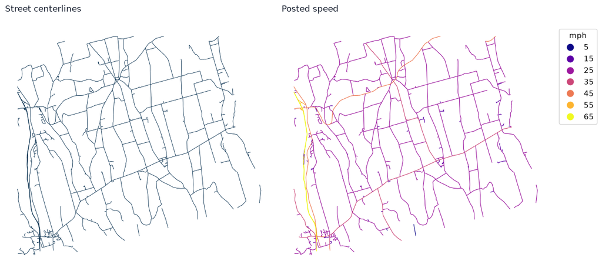

```python
# Side-by-side street centerlines and categorical posted-speed map.
fig, axes = plt.subplots(1, 2, figsize=(12, 6))  # two street-map panels
# Draw one map layer.
plot_layer(
    streets,  # all centerlines in one style
    "Street centerlines",  # left title
    ax=axes[0],  # left panel
    facecolor=EDGE,  # line color (facecolor used for lines here)
    linewidth=0.6,  # centerline stroke width
    axis_off=True,  # hide axes
)  # close this call
# Draw one map layer.
plot_layer(
    streets,  # same streets colored by SPEED
    "Posted speed",  # right title
    ax=axes[1],  # right panel
    column="SPEED",  # posted speed limit
    categorical=True,  # treat mph values as categories
    cmap="plasma",  # categorical/continuous-looking ramp
    linewidth=0.8,  # slightly thicker for class colors
    legend=True,  # show mph legend
    axis_off=True,  # hide axes
    legend_kwds={"title": "mph", "loc": "upper left", "bbox_to_anchor": (1.02, 1)},  # outside legend
)  # close this call
fig.tight_layout()  # tighten the two panels
plt.show()  # display the street maps
```

### Street type

`Road_type` is a category derived from `PostType`. Roads dominate the file, and the other classes are the remaining suffixes a reader can still see in the legend.

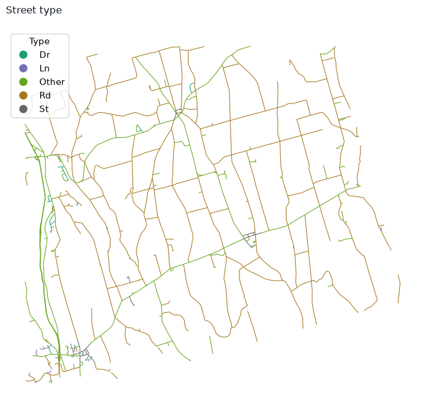

```python
# Categorical map of simplified street types (Rd, St, Ln, Dr, Other).
plot_categorical(
    streets,  # street centerlines
    "Road_type",  # simplified type column
    "Street type",  # map title
    cmap="Dark2",  # qualitative colormap
    linewidth=0.8,  # line stroke width
    figsize=(8, 7),  # figure size
    axis_off=True,  # hide axes
    legend_kwds={"title": "Type", "loc": "upper left"},  # legend placement
)  # close this call
```

### Streets on the counties they cross

The segments intersect Onondaga County and Cortland County. Both layers already share NAD83 Albers. The county fill is drawn at `zorder` 1 and the streets at `zorder` 2, so the lines stay visible. This is the same overlay pattern as the GeoPandas guide: create the axes with the area layer, then draw the next layer onto that axes.

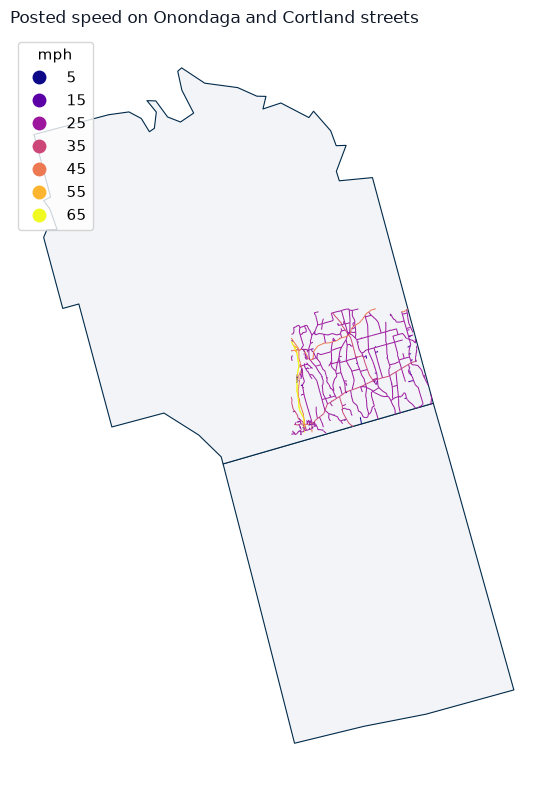

```python
# Overlay posted speed on Onondaga and Cortland county polygons.
crossed = counties.loc[
    counties["STATE"].eq("New York")  # New York only
    & counties["COUNTY"].isin(["Onondaga County", "Cortland County"])  # two counties
].copy()  # local copy for plotting

# Compose multiple map layers.
plot_layers(
    # List of layer style dictionaries.
    [
        # One layer style dictionary.
        {
            "data": crossed,  # county underlay
            "facecolor": "#F2F4F7",  # light gray fill
            "edgecolor": EDGE,  # county outline
            "linewidth": 0.8,  # outline width
            "zorder": 1,  # under the streets
        },  # end this layer dict
        # One layer style dictionary.
        {
            "data": streets,  # street overlay
            "column": "SPEED",  # color by posted speed
            "categorical": True,  # categorical mph classes
            "cmap": "plasma",  # colormap for SPEED
            "linewidth": 0.7,  # street stroke width
            "legend": True,  # show mph legend
            "legend_kwds": {"title": "mph", "loc": "upper left"},  # legend options
            "zorder": 2,  # above the counties
        },  # end this layer dict
    ],  # end layer list
    title="Posted speed on Onondaga and Cortland streets",  # map title
    figsize=(8, 8),  # square figure
    legend=False,  # layer-level legend handles SPEED instead
    axis_off=True,  # hide axes
)  # close this call
```

County names and a scale bar finish the static line map. The labels use the county layer; the streets stay unlabeled because several hundred names will not fit.

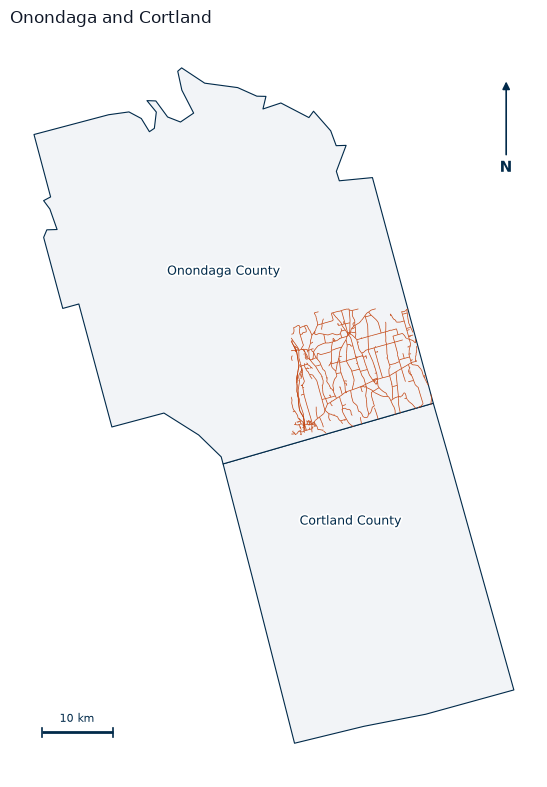

```python
# County underlay with street overlay, county labels, and cartographic elements.
ax = plot_layers(
    # List of layer style dictionaries.
    [
        # One layer style dictionary.
        {
            "data": crossed,  # Onondaga + Cortland polygons
            "facecolor": "#F2F4F7",  # light fill
            "edgecolor": EDGE,  # county outline
            "linewidth": 0.8,  # outline width
            "zorder": 1,  # under streets
        },  # end this layer dict
        # One layer style dictionary.
        {
            "data": streets,  # street centerlines
            "facecolor": "#C2410C",  # orange-red line color
            "linewidth": 0.5,  # thin streets for label clarity
            "zorder": 2,  # above counties
        },  # end this layer dict
    ],  # end layer list
    title="Onondaga and Cortland",  # map title
    figsize=(8, 8),  # square figure
    legend=False,  # no legend needed for this composition
    axis_off=True,  # hide axes
    show=False,  # return axes for labels/elements
)  # close this call
add_labels(ax, crossed, "COUNTY", fontsize=9)  # label each county
cartographic_elements(ax, crossed)  # north arrow / scale bar
ax.figure.tight_layout()  # tighten layout
plt.show()  # display the labeled map
```

### Tile basemap

Web tiles are drawn in Web Mercator (EPSG:3857). `plot_layers(..., basemap=True)` reprojects the layers to that CRS and then calls `contextily`, which is the same tile mechanism GeoPandas uses for `plot(tiles=...)`. `OpenStreetMap.HOT` is a provider from that catalog and does not need an API key. `CartoDB.Positron` is another common name; some Carto endpoints now return a key warning instead of a map. The cell needs a network connection to the tile service. Reprojecting first keeps the tiles sharp; asking contextily to warp the image into Albers softens it.

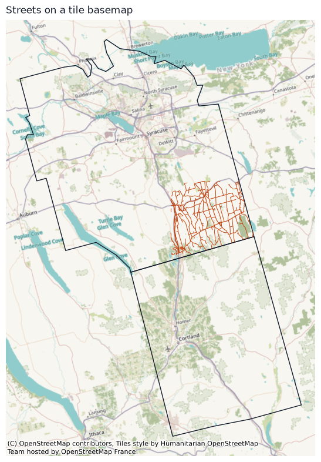

```python
# Streets and county outlines drawn over an OpenStreetMap.HOT tile basemap.
plot_layers(
    # List of layer style dictionaries.
    [
        # One layer style dictionary.
        {
            "data": crossed,  # county outlines only
            "facecolor": "none",  # no fill so tiles show through
            "edgecolor": "#101828",  # dark outline
            "linewidth": 1.0,  # stronger outline on tiles
            "zorder": 2,  # above the basemap
        },  # end this layer dict
        # One layer style dictionary.
        {
            "data": streets,  # street overlay
            "facecolor": "#C2410C",  # orange-red streets
            "linewidth": 0.7,  # street stroke width
            "zorder": 3,  # above county outlines
        },  # end this layer dict
    ],  # end layer list
    basemap=True,  # enable a contextily/tile basemap
    basemap_source="OpenStreetMap.HOT",  # Humanitarian OSM tiles
    title="Streets on a tile basemap",  # map title
    figsize=(8, 8),  # square figure
    legend=False,  # no legend for this basemap view
)  # close this call
```

### Interactive line layer

The county outline and the speed-limit lines share one Folium map. Passing a list of layers to `interactive_map` adds a layer control. Hover a segment for its street label and speed. The map opens near the center of the street layer.

`explore` writes every attribute into the web layer. The street file has dozens of address fields the tooltip does not use, so the interactive layer keeps `Label`, `SPEED`, and `Road_type` only.

```python
# Interactive Folium map with county outlines and streets colored by SPEED.
street_center = streets.to_crs(4326).geometry.union_all().centroid  # center in lon/lat
street_web = streets[["Label", "SPEED", "Road_type", "geometry"]].copy()  # slim web layer
# Build an interactive Folium map.
interactive_map(
    # List of layer style dictionaries.
    [
        # One layer style dictionary.
        {
            "data": crossed[["COUNTY", "geometry"]],  # county polygons for outline
            "name": "Counties",  # Folium layer name
            "color": EDGE,  # outline color
            "tooltip": ["COUNTY"],  # hover field
            "style_kwds": {"fillOpacity": 0.05, "weight": 1.5, "color": EDGE},  # light fill
        },  # end this layer dict
        # One layer style dictionary.
        {
            "data": street_web,  # street segments for the web map
            "name": "Posted speed",  # Folium layer name
            "column": "SPEED",  # color by mph
            "categorical": True,  # categorical SPEED classes
            "cmap": "plasma",  # colormap
            "tooltip": ["Label", "SPEED", "Road_type"],  # hover fields
        },  # end this layer dict
    ],  # end layer list
    tiles="OpenStreetMap",  # basemap tiles
    location=[street_center.y, street_center.x],  # Folium [lat, lon]
    zoom_start=11,  # city/county-scale zoom
    height="520px",  # iframe height
)  # close this call
```

Make this Notebook Trusted to load map: File -> Trust Notebook

[interactive chart not shown]

## Summary

Use a single symbol when the question is location. Use a choropleth when the question is a quantity attached to an area, and choose the classification for the distribution you have: quantiles when each class should contain a similar number of places, equal interval when the legend must be even steps of the attribute, and natural breaks when the classes should follow clusters in the data. Use a qualitative palette for names and codes. Mark missing values explicitly. Put every layer in one CRS before you overlay them, and use Folium when the reader needs to zoom, inspect a feature, or switch a layer off.